# Raster Deepdive: Tasks

Author

Etienne

Published

March 16, 2026

# 🚀 Tasks

Follow the instructions in `Submission via GitHub Pages` to create a new repo in the existing organization. As you did in the previous weeks, solve the next task in a file named `index.qmd`.

## Task 1

1. Redo `Task 1` from *Vector Deepdive* (calculate the percentage of forest per canton). However, this time use the R package `terra` to do the processing.
2. Again, use the R package `tictoc` to measure the execution time of each step in the process.

## Solution 1

```r
library(terra)
library(tidyverse)
library(tictoc)
library(duckdb)
library(sf)
```

### Loading the Data

With `terra::vect()`, GeoPackages can be read in. Using the `layer` argument, we can specify which layer should be read from the GeoPackage. For the cantonal boundaries we need `tlm_kantonsgebiet`, and for the land-use data we need `tlm_bb_bodenbedeckung`.

```r
canton_polygons <- terra::vect(
  "data/swissBOUNDARIES3D_1_5_LV95_LN02.gpkg",
  layer = "tlm_kantonsgebiet"
  )
```

```r
land_use_polygons <- terra::vect(
  "data/SWISSTLM3D_2025.gpkg",
  layer = "tlm_bb_bodenbedeckung"
  )
```

### Quick Visual Check

Let’s get a quick visual confirmation that we imported reasonable things. We can do this using some quick-and-dirty plotting — terra works well with the standard `plot()` function.

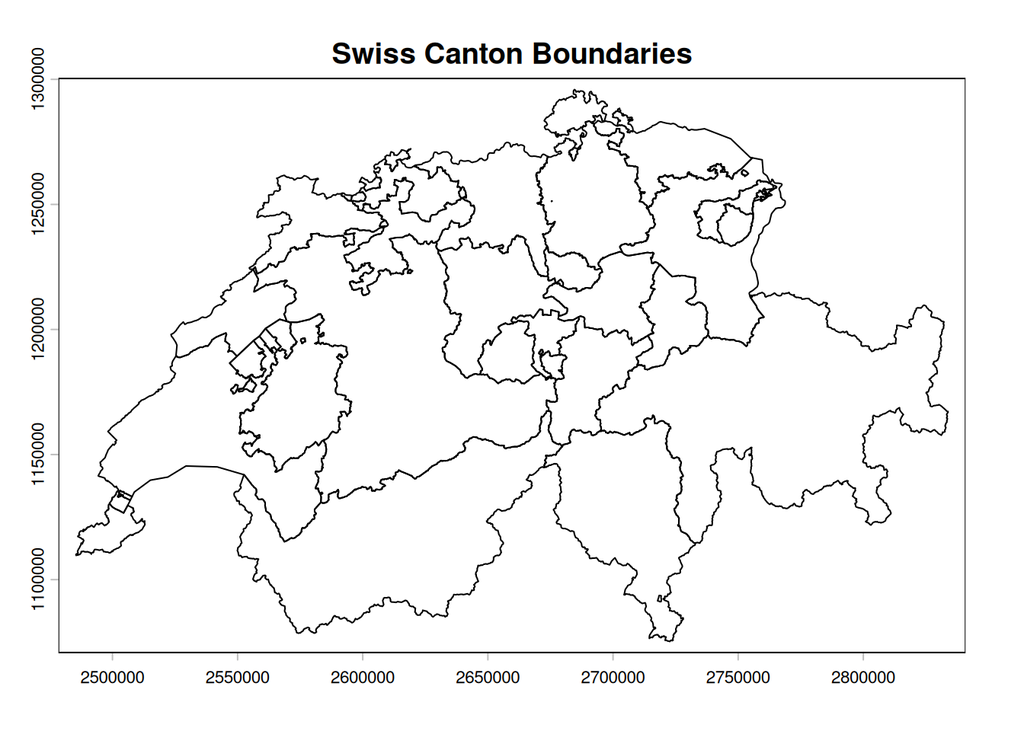

```r
plot(canton_polygons, main = "Swiss Canton Boundaries")
```

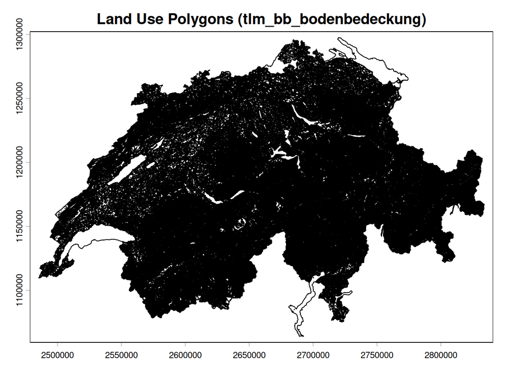

```r
plot(land_use_polygons, main = "Land Use Polygons (tlm_bb_bodenbedeckung)")
```

### Rasterizing Canton Polygons

Theoretically, terra also features some support for manipulating vector data. However, since this is a raster deepdive, I decided to rasterize the vector data at this point and carry out the analysis purely using raster operations.

Rasterizing requires a raster as a blueprint for the conversion. From it, attributes such as the cell size and CRS are taken. We can create such a template raster quite easily: I will create one with the extent and the coordinate system of the respective vector data. The resolution is generally open to the user to choose. I am going with a 100m cell size. Generally, the smaller the cell size, the smaller the quantization error from vector to raster data, but compute time also increases.

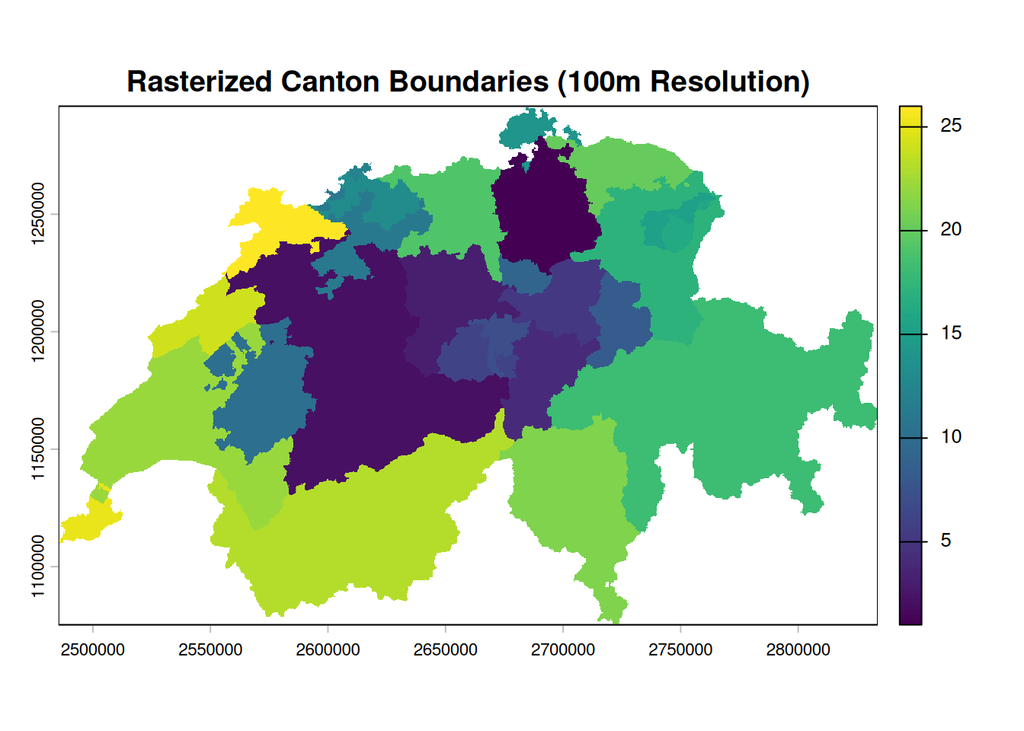

```r
template_canton <- rast(
  extent = ext(canton_polygons),   # take the extend from the canton polygon dataset
  resolution = 100,        # set the resolution of the raster (here 100m x 100m)
  crs = crs(canton_polygons)        # same CRS as the canton polygons
)

canton_raster <- rasterize(canton_polygons,template_canton, field = "kantonsnummer")


plot(canton_raster, main = "Rasterized Canton Boundaries (100m Resolution)")
```

### Rasterizing Forest Polygons

For the land-use data, we need to be aware that land-use polygons can overlap. This causes problems when rasterizing, because each cell can only hold one value. The easiest way to handle this is to apply a filter operation on the polygons before rasterization. (So in the end, I still had to do some vector data manipulation). The `field` parameter sets the burn-in value for the raster. I am choosing 100 here, as this will make the calculation of the percentage forest cover very easy in a later step. For areas where no forest polygon lies, I assign the value 0.

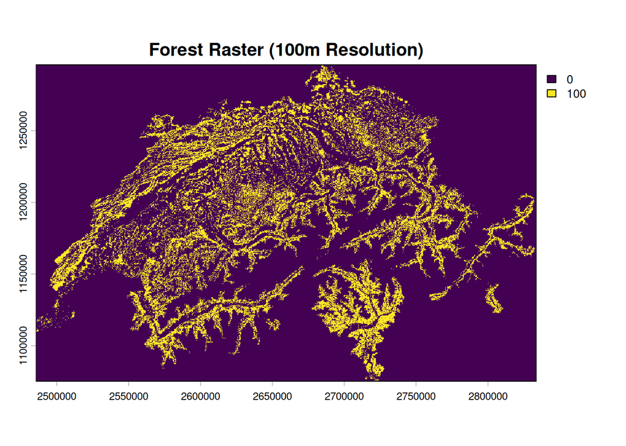

```r
forest_polygons <- land_use_polygons[land_use_polygons$objektart == "Wald"]


forest_template <- rast(
  extent = ext(canton_polygons),    # take the extend from the canton polygon dataset
  resolution = 100,        # set the resolution of the raster (here 100m x 100m)
  crs = crs(canton_polygons)        # same CRS as the canton polygons
)

# All forested areas get the value 100, all other areas get 0.
forest_raster <- rasterize(forest_polygons, forest_template, field = 100, background = 0)

plot(forest_raster, main = "Forest Raster (100m Resolution)")
```

(**Note** : I’m also taking the extend of the canton polygons here, even tough I am rasterising the forest polygons. This will make the `zonal statistics` step easier. Terra is very strict when it comes to extends, and `zonal operations (and many other functionallities) only work, if all the input rasters have the same extent)

### Calculating Percentage Forest Cover

Now, in order to get the forest coverage per canton, we can perform a zonal operation. The forest raster has only two distinct values: 100 for forest pixels and 0 for non-forest pixels. Due to this, we can calculate the percentage of cantonal area covered by forest rather easily by applying the mean function to every canton zone.

Calculating the mean of the forest raster performs the following operation:

$$\begin{aligned}
\text{mean}(\text{pixel values}) &= \frac{\sum \text{pixel values}}{n_{\text{pixels total}}} \\
&= \frac{\sum(100,\ 0,\ 0,\ \ldots,\ 100)}{n_{\text{pixels total}}} \\
&= \frac{100 \cdot \sum(1,\ 0,\ 0,\ \ldots,\ 1)}{n_{\text{pixels total}}} \\
&= 100 \cdot \frac{n_{\text{forest pixels}}}{n_{\text{pixels total}}}
\end{aligned}$$

So the mean directly gives the percentage forest cover for every canton.

```r
# get the kanton numbers and their corresponding names (for the join later on)
kanton_number_keys <- canton_polygons %>% as.data.frame() %>%
    select(name, kantonsnummer)

# Compute the forest coverage using zonal operations
forest_are_per_canton <- zonal(forest_raster, canton_raster, fun = "mean") %>%
                            as_tibble() %>%
                            mutate(
                                percentual_forest_cover = layer
                            ) %>%
                              inner_join(
                                kanton_number_keys,
                                by = join_by(kantonsnummer == kantonsnummer)
                                ) %>%
                                  select(!c(layer, kantonsnummer)) %>%
                                  arrange(desc(percentual_forest_cover))

forest_are_per_canton
```

```
# A tibble: 26 × 2
   percentual_forest_cover name
                     <dbl> <chr>
 1                    42.5 Ticino
 2                    42.0 Schaffhausen
 3                    40.5 Solothurn
 4                    40.1 Jura
 5                    39.1 Basel-Landschaft
 6                    35.4 Obwalden
 7                    34.9 Aargau
 8                    34.2 Neuchâtel
 9                    31.6 Appenzell Ausserrhoden
10                    30.3 Nidwalden
# ℹ 16 more rows
```

### Performing Timing

Now let’s measure this with tictoc. To make later comparison with GDAL fair, the data reading step is also included. (Technically, writing the resulting raster should also be included here, as GDAL has to do this step too).

```r
tic("Terra Total:")

tic("terra: load canton polygons")
canton_polygons <- terra::vect("data/swissBOUNDARIES3D_1_5_LV95_LN02.gpkg", layer = "tlm_kantonsgebiet")
toc()
```

```
terra: load canton polygons: 0.02 sec elapsed
```

```r
tic("terra: load land use polygons")
land_use_polygons <- terra::vect("data/SWISSTLM3D_2025.gpkg", layer = "tlm_bb_bodenbedeckung")
toc()
```

```
terra: load land use polygons: 6.581 sec elapsed
```

```r
tic("terra: rasterize canton polygons")
template_canton <- rast(
  extent = ext(canton_polygons),   # takes extent from your vector
  resolution = 100,        # set your desired resolution (in map units, e.g. meters)
  crs = crs(canton_polygons)        # same CRS as your vector
)
canton_raster <- rasterize(canton_polygons, template_canton, field = "kantonsnummer")
toc()
```

```
terra: rasterize canton polygons: 0.194 sec elapsed
```

```r
tic("terra: filter and rasterize forest polygons")
forest_polygons <- land_use_polygons[land_use_polygons$objektart == "Wald"]

forest_template <- rast(
  extent = ext(canton_polygons),   # extent of canton polygons
  resolution = 100,        # set your desired resolution (in map units, e.g. meters)
  crs = crs(canton_polygons)        # crs of canton polygons
)

# All forested areas get the value 100, all other areas get 0.
forest_raster <- rasterize(forest_polygons, forest_template, field = 100, background = 0)
toc()
```

```
terra: filter and rasterize forest polygons: 4.1 sec elapsed
```

```r
tic("terra: zonal statistics")
kanton_number_keys <- canton_polygons %>% as.data.frame() %>%
    select(name, kantonsnummer)

forest_are_per_canton <- zonal(forest_raster, canton_raster, fun = "mean") %>%
                            as_tibble() %>%
                            mutate(
                                percentual_forest_cover = layer
                            ) %>%
                                inner_join(
                                    kanton_number_keys,
                                    by = join_by(kantonsnummer == kantonsnummer)
                                ) %>%
                                    select(!c(layer, kantonsnummer)) %>%
                                    arrange(desc(percentual_forest_cover))
toc()
```

```
terra: zonal statistics: 0.108 sec elapsed
```

```r
toc()
```

```
Terra Total:: 11.005 sec elapsed
```

## Task 2

1. Redo `Task 1` from *Vector Deepdive*. However, this time use `gdal` from the command line to do the processing. Note that you can use `bash` commands in quarto, you just have to
   - set the language to `{bash}` in the code chunk and
   - the `engine` to `knitr` in the YAML header
2. Again, use the R package `tictoc` to measure the execute time of each step in the process. To measure the execution time of bash commands, you can use the approach shown below (which is a bit of a workaround since tictoc was made for R, not Bash commands)
3. Compare the execution times of all approaches (`sf`, `duckdb`, `terra`, `gdal`). How do they differ?

## Solution 2

For this exercise I first created a conda environment and installed GDAL.

```bash
# Create the environment
conda create -n gdal_environment
```

```bash
# Activate the environment
conda activate gdal_environment
```

```bash
# Install GDAL
conda install -c conda-forge gdal
```

### Rasterizing Canton Polygons

Analogous to Task 1, I first rasterize the canton polygons, again using a 100m × 100m cell size to keep the terra and GDAL workflows comparable. GDAL processes data in a streaming fashion, so the input and output files must be explicitly specified via `--input` and `--output`. The `-a` flag defines the attribute field from which burn-in values are taken — in our case, the cantonal number. The `-l` flag specifies which layer from the GeoPackage should be read.

```bash
gdal vector rasterize -l tlm_kantonsgebiet \
        --resolution 100,100 \
        --input ./data/swissBOUNDARIES3D_1_5_LV95_LN02.gpkg \
        -a kantonsnummer \
        --overwrite \
        --output ./data/kantone_raster
```

### Rasterizing Forest Polygons

The forest polygons also need to be rasterized, again at 100m × 100m resolution to keep the workflows comparable. As the burn-in value I am picking 100, so that calling `mean` in the zonal statistics step directly yields the percentage forest cover. Areas not covered by a forest polygon are initialized to 0. GDAL treats 0 as the default NoData value, which would be ignored in statistical aggregations. This is problematic here, since 0 carries a vital meaning in our calculation. To work around this, I set the NoData value to 255.

```bash
gdal vector rasterize --where "objektart='Wald'" \
        -l tlm_bb_bodenbedeckung \
        --resolution 100,100 \
        --input ./data/SWISSTLM3D_2025.gpkg \
        --overwrite \
        --nodata 255 \
        --init 0 \
        --burn 100 \
        --output ./data/forest_raster_cent
```

### Calculation of Percentage Forest Cover

The new GDAL API also features a function for zonal operations. Under `--input`, the raster to aggregate is passed. Under `--zones`, the raster providing the zones is passed. `--stat` defines the aggregation function — mean is the correct choice here for the reasons explained above. The output is in tabular format with one aggregated value per zone, stored as a CSV.

```bash
gdal raster zonal-stats --input ./data/forest_raster_cent \
        --zones ./data/kantone_raster \
        --stat=mean \
        --overwrite \
        --output ./data/cantonal_forest_percent.csv
```

Lastly, to make interpretation easier, the canton names can be joined into the resulting CSV. For this, `gdal vector sql` can be used — it conveniently allows SQL queries across tabular data from different file types.

```bash
gdal vector sql \
    --input ./data/cantonal_forest_percent.csv \
    --dialect sqlite \
    --sql "SELECT z.value AS kantonsnummer, k.name, z.mean
           FROM cantonal_forest_percent z
           JOIN './data/swissBOUNDARIES3D_1_5_LV95_LN02.gpkg'.tlm_kantonsgebiet k
           ON CAST(z.value AS INTEGER) = k.kantonsnummer
           ORDER BY z.mean DESC" \
    --format CSV \
    --overwrite \
    --output final_analysis_results.csv

cat final_analysis_results.csv
```

```
0...10...20...30...40...50...60...70...80...90...100 - done.
kantonsnummer,name,mean
"21",Ticino,"42.4556598632008"
"14",Schaffhausen,"41.9084555752999"
"11",Solothurn,"40.4652159152839"
"26",Jura,"39.9744597932356"
"13",Basel-Landschaft,"39.1647851774916"
"6",Obwalden,"35.5066592528873"
"19",Aargau,"34.8845934643401"
"24",Neuchâtel,"34.248927831434"
"15",Appenzell Ausserrhoden,"31.5914752388803"
"7",Nidwalden,"30.2175218713081"
"5",Schwyz,"29.8504261374627"
"22",Vaud,"29.4353653694488"
"1",Zürich,"29.139057668338"
"2",Bern,"27.8978574571713"
"16",Appenzell Innerrhoden,"27.5699397664448"
"3",Luzern,"27.2246142112414"
"17",St. Gallen,"26.4101231683084"
"9",Zug,"26.0472814562633"
"10",Fribourg,"25.0485622110094"
"8",Glarus,"24.2232266474071"
"18",Graubünden,"22.7212822937171"
"20",Thurgau,"20.127363399439"
"23",Valais,"20.0336262104377"
"4",Uri,"14.3326812967947"
"12",Basel-Stadt,"12.0980130625783"
"25",Genève,"11.4553194965219"
```

### Performing Timing

As already mentioned in the task description, timing is not straightforward here since tictoc is an R library. The workaround is to wrap the bash block containing all commands between two R chunks calling `tic()` and `toc()`.

```r
tictoc::tic("GDAL: total")
tictoc::tic("GDAL: rasterize canton polygons")
```

```bash
gdal vector rasterize -l tlm_kantonsgebiet \
        --resolution 100,100 \
        --input ./data/swissBOUNDARIES3D_1_5_LV95_LN02.gpkg \
        -a kantonsnummer \
        --overwrite \
        --output ./data/kantone_raster
```

```r
tictoc::toc()
```

```
GDAL: rasterize canton polygons: 0.261 sec elapsed
```

```r
tictoc::tic("GDAL: rasterize forest polygons")
```

```bash
gdal vector rasterize --where "objektart='Wald'" \
        -l tlm_bb_bodenbedeckung \
        --resolution 100,100 \
        --input ./data/SWISSTLM3D_2025.gpkg \
        --overwrite \
        --nodata 255 \
        --init 0 \
        --burn 100 \
        --output ./data/forest_raster_cent
```

```r
tictoc::toc()
```

```
GDAL: rasterize forest polygons: 2.162 sec elapsed
```

```r
tictoc::tic("GDAL: zonal statistics")
```

```bash
gdal raster zonal-stats --input ./data/forest_raster_cent \
        --zones ./data/kantone_raster \
        --stat=mean \
        --overwrite \
        --output ./data/cantonal_forest_percent.csv
```

```r
tictoc::toc()
```

```
GDAL: zonal statistics: 0.436 sec elapsed
```

```r
tictoc::tic("GDAL: SQL join")
```

```bash
gdal vector sql \
    --input ./data/cantonal_forest_percent.csv \
    --dialect sqlite \
    --sql "SELECT z.value AS kantonsnummer, k.name, z.mean
           FROM cantonal_forest_percent z
           JOIN './data/swissBOUNDARIES3D_1_5_LV95_LN02.gpkg'.tlm_kantonsgebiet k
           ON CAST(z.value AS INTEGER) = k.kantonsnummer
           ORDER BY z.mean DESC" \
    --format CSV \
    --overwrite \
    --output final_analysis_results.csv
```

```r
tictoc::toc()
```

```
GDAL: SQL join: 0.155 sec elapsed
```

```r
tictoc::toc()
```

```
GDAL: total: 3.017 sec elapsed
```

### Speed Comparison

To complete the comparison, here are the timings for the `sf` and DuckDB approaches from the previous exercise.

**sf**

```r
tictoc::tic("sf")

canton_polygons <- st_read(
  "./data/swissBOUNDARIES3D_1_5_LV95_LN02.gpkg",
  layer = "tlm_kantonsgebiet",
  quiet = TRUE

)

# and also the ground cover polygons
ground_cover_polygons <- st_read(
  "./data/SWISSTLM3D_2025.gpkg",
  layer = "tlm_bb_bodenbedeckung",
  quiet = TRUE
)



forest_polygons <- ground_cover_polygons %>%
  filter(objektart == "Wald")

forest_in_cantons <- forest_polygons %>%
  st_intersection(canton_polygons) %>%
  mutate(
    forest_area = st_area(geom)
  ) %>%
  group_by(name) %>%
  summarise(
    total_forest_area = sum(forest_area)
  )

percentual_forest_per_canton <- canton_polygons %>%
  mutate(
    cantonal_area = st_area(geom)
  ) %>%
  left_join(
    st_drop_geometry(forest_in_cantons),
    by = "name"
    ) %>%
  mutate(
    forest_pct = as.numeric(total_forest_area / cantonal_area) * 100
  )

tictoc::toc()
```

```
sf: 329.28 sec elapsed
```

**DuckDB**

```r
con <- dbConnect(
  duckdb(),
  dbdir = "./../vector-deepdive/data/wald-kantone.duckdb",
  read_only = TRUE
)

invisible(dbExecute(con, "LOAD spatial;"))

tictoc::tic("DuckDB")
canton_frac <- dbReadTable(con, "cantonal_forest_fractions")
tictoc::toc()
```

```
DuckDB: 154.916 sec elapsed
```

### Interpretation

#### GDAL vs. terra

The GDAL workflow is the fastest of all approaches, beating the terra workflow by a factor of approximately 4×. Was rather surprising to me, because GDAL reads from and writes to disk multiple times during its workflow. I had always assumed that, due to a concept known as the [Zugriffslücke](https://wwwlehre.dhbw-stuttgart.de/~kfg/db/dbMA.pdf) — the large performance gap between memory and disk access — such workflows should carry a severe disadvantage. So what causes the speed difference between `GDAL` and `terra`? It might be that there is some additional overhead caused by `R` resulting in slower exection speed in `terra`, but ultimately I do not know.

#### Raster-based vs. vector-based

In terms of speed, both raster-based workflows (GDAL and terra) are clearly faster than the vector-based ones, performing the same analysis in a fraction of the time.

This result has to be taken with a grain of salt however. Through rasterization we lose precision, which might be important in a given project. To obtain more precise results, one would need to choose smaller cell sizes, which in turn increases compute time and narrows the speed gap with the vector-based approaches. So the speed advantage at least partially stems from a trade-off with accuracy.

# Usage of KI

Claude Sonnet (Anthropic) was used as an aid for this exercise. It was used to review the submitted document, identify and fix inconsistencies in file naming across code chunks, add the required `_quarto.yml` configuration and YAML front matter, and perform spell-checking and formatting of the written explanations. Furthermore, it was used to convert the algebraic derivation to LaTeX.